# SakinaSaifuddin_Lab2

```python
import warnings
warnings.filterwarnings('ignore')
```

**Q1: Load the data.**

```python
import pandas as pd
import numpy as np
import matplotlib.pyplot as plt
import seaborn as sns
from sklearn.model_selection import train_test_split

heart = pd.read_csv('Heart.csv', index_col=0)
print(heart.head())

df = pd.DataFrame(heart)
```

```
   Age  Sex     ChestPain  RestBP  Chol  Fbs  RestECG  MaxHR  ExAng  Oldpeak  \
1   63    1       typical     145   233    1        2    150      0      2.3
2   67    1  asymptomatic     160   286    0        2    108      1      1.5
3   67    1  asymptomatic     120   229    0        2    129      1      2.6
4   37    1    nonanginal     130   250    0        0    187      0      3.5
5   41    0    nontypical     130   204    0        2    172      0      1.4

   Slope   Ca        Thal  AHD
1      3  0.0       fixed   No
2      2  3.0      normal  Yes
3      2  2.0  reversable  Yes
4      3  0.0      normal   No
5      1  0.0      normal   No
```

**Q1: How many variables in the dataset? What are they? Are they quantitative or qualitative variables? Is there any missing value?**

```python
print("The number of variables are:", df.shape[1]) #gets number of total variables

print("The variable names are:" , list(df.columns))

print(df.info())

# ── Based on data types
quantitative_vars = df.select_dtypes(include=["int64", "float64"]).columns.tolist()
qualitative_vars  = df.select_dtypes(include=["object"]).columns.tolist()

# ── Print results
print(f"Total variables: {df.shape[1]}")
print()
print(f"Quantitative variables ({len(quantitative_vars)}): {quantitative_vars}")
print()
print(f"Qualitative variables ({len(qualitative_vars)}): {qualitative_vars}")


# ── Missing value check
print("Missing values per variable:")
print(df.isnull().sum())
print()
print(f"Total missing values: {df.isnull().sum().sum()}")
```

```
The number of variables are: 14
The variable names are: ['Age', 'Sex', 'ChestPain', 'RestBP', 'Chol', 'Fbs', 'RestECG', 'MaxHR', 'ExAng', 'Oldpeak', 'Slope', 'Ca', 'Thal', 'AHD']
<class 'pandas.core.frame.DataFrame'>
Index: 303 entries, 1 to 303
Data columns (total 14 columns):
 #   Column     Non-Null Count  Dtype
---  ------     --------------  -----
 0   Age        303 non-null    int64
 1   Sex        303 non-null    int64
 2   ChestPain  303 non-null    object
 3   RestBP     303 non-null    int64
 4   Chol       303 non-null    int64
 5   Fbs        303 non-null    int64
 6   RestECG    303 non-null    int64
 7   MaxHR      303 non-null    int64
 8   ExAng      303 non-null    int64
 9   Oldpeak    303 non-null    float64
 10  Slope      303 non-null    int64
 11  Ca         299 non-null    float64
 12  Thal       301 non-null    object
 13  AHD        303 non-null    object
dtypes: float64(2), int64(9), object(3)
memory usage: 35.5+ KB
None
Total variables: 14

Quantitative variables (11): ['Age', 'Sex', 'RestBP', 'Chol', 'Fbs', 'RestECG', 'MaxHR', 'ExAng', 'Oldpeak', 'Slope', 'Ca']

Qualitative variables (3): ['ChestPain', 'Thal', 'AHD']
Missing values per variable:
Age          0
Sex          0
ChestPain    0
RestBP       0
Chol         0
Fbs          0
RestECG      0
MaxHR        0
ExAng        0
Oldpeak      0
Slope        0
Ca           4
Thal         2
AHD          0
dtype: int64

Total missing values: 6
```

**Q2. Impute the missing value using mean value for quantitative variable and majority class for qualitative variable.**

```python
# ── Before
print("Before imputation:")
print(df.isnull().sum())

# ── Impute Ca (quantitative) with mean
df["Ca"]   = df["Ca"].fillna(df["Ca"].mean())

# ── Impute Thal (qualitative) with majority class
df["Thal"] = df["Thal"].fillna(df["Thal"].mode()[0])

# ── After
print("\nAfter imputation:")
print(df.isnull().sum())
```

```
Before imputation:
Age          0
Sex          0
ChestPain    0
RestBP       0
Chol         0
Fbs          0
RestECG      0
MaxHR        0
ExAng        0
Oldpeak      0
Slope        0
Ca           4
Thal         2
AHD          0
dtype: int64

After imputation:
Age          0
Sex          0
ChestPain    0
RestBP       0
Chol         0
Fbs          0
RestECG      0
MaxHR        0
ExAng        0
Oldpeak      0
Slope        0
Ca           0
Thal         0
AHD          0
dtype: int64
```

## **Q3. Data visualization.**

**a) Please use the boxplots to visualize the relationship of quantitative predictor with outcome (AHD).**

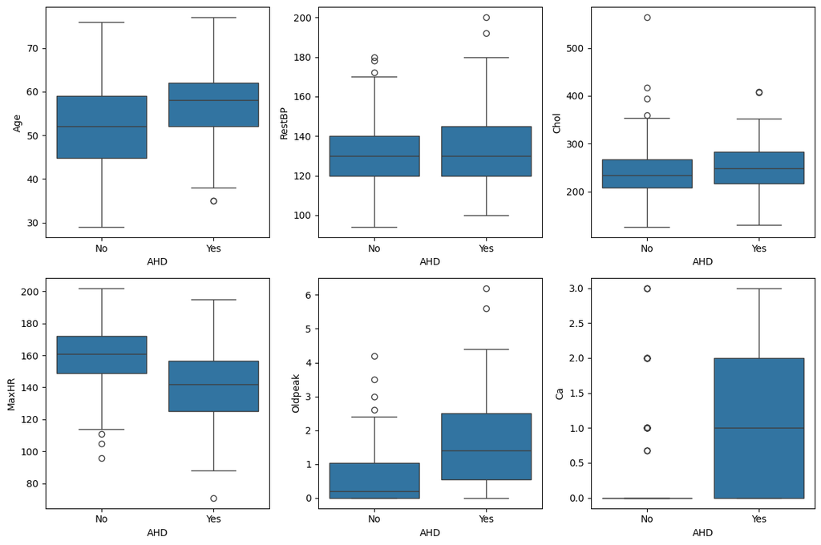

```python
# a) Boxplots
plt.figure(figsize=(12, 8))

plt.subplot(2, 3, 1)
sns.boxplot(x='AHD', y='Age', data=df)

plt.subplot(2, 3, 2)
sns.boxplot(x='AHD', y='RestBP', data=df)

plt.subplot(2, 3, 3)
sns.boxplot(x='AHD', y='Chol', data=df)

plt.subplot(2, 3, 4)
sns.boxplot(x='AHD', y='MaxHR', data=df)

plt.subplot(2, 3, 5)
sns.boxplot(x='AHD', y='Oldpeak', data=df)

plt.subplot(2, 3, 6)
sns.boxplot(x='AHD', y='Ca', data=df)

plt.tight_layout()
plt.show()
```

Patients with heart disease (AHD=Yes) tend to be older, have lower MaxHR, higher Oldpeak, and more blocked vessels (Ca), making these three the strongest predictors. RestBP shows a slight difference while Chol shows almost no difference between the two groups.

**b) Please use the corrplots to visualize the correlations between quantitative variables.**

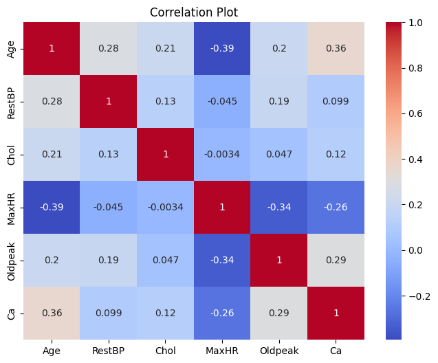

```python
import matplotlib.pyplot as plt
import seaborn as sns

quant_vars = ["Age", "RestBP", "Chol", "MaxHR", "Oldpeak", "Ca"]

plt.figure(figsize=(8, 6))
sns.heatmap(df[quant_vars].corr(), annot=True, cmap="coolwarm")
plt.title("Correlation Plot")
plt.show()
```

Overall, no strong correlations (above 0.70) exist between any two variables, meaning multicollinearity is not a concern in this dataset

**c) Please use the scatterplots to find the patterns in predictors that distinguish AHD=Yes and AHD=No patients.**

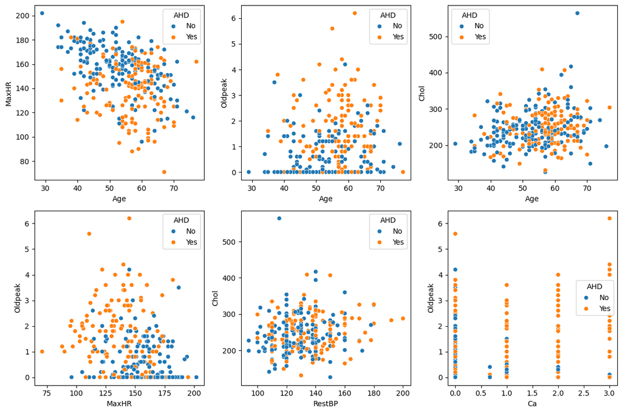

```python
import matplotlib.pyplot as plt
import seaborn as sns

plt.figure(figsize=(12, 8))

plt.subplot(2, 3, 1)
sns.scatterplot(x='Age', y='MaxHR', hue='AHD', data=df)

plt.subplot(2, 3, 2)
sns.scatterplot(x='Age', y='Oldpeak', hue='AHD', data=df)

plt.subplot(2, 3, 3)
sns.scatterplot(x='Age', y='Chol', hue='AHD', data=df)

plt.subplot(2, 3, 4)
sns.scatterplot(x='MaxHR', y='Oldpeak', hue='AHD', data=df)

plt.subplot(2, 3, 5)
sns.scatterplot(x='RestBP', y='Chol', hue='AHD', data=df)

plt.subplot(2, 3, 6)
sns.scatterplot(x='Ca', y='Oldpeak', hue='AHD', data=df)

plt.tight_layout()
plt.show()
```

## **Q4. Please separate the dataset into training and testing data with ratio of 3:1.**

```python
# Convert categorical to numerical
heart_encoded = pd.get_dummies(df, columns=["ChestPain", "Thal"], drop_first=True)
heart_encoded["AHD"] = heart_encoded["AHD"].map({"No": 0, "Yes": 1})

# Separate features and target
X = heart_encoded.drop(columns=["AHD"])
y = heart_encoded["AHD"]

# Split 75% train, 25% test (3:1 ratio)
X_train, X_test, y_train, y_test = train_test_split(X, y, test_size=0.25, random_state=42)

print(f"Total samples : {len(df)}")
print(f"Training size : {len(X_train)}")
print(f"Testing size  : {len(X_test)}")
heart_encoded
```

```
Total samples : 303
Training size : 227
Testing size  : 76
```

|  | Age | Sex | RestBP | Chol | Fbs | RestECG | MaxHR | ExAng | Oldpeak | Slope | Ca | AHD | ChestPain_nonanginal | ChestPain_nontypical | ChestPain_typical | Thal_normal | Thal_reversable |
| --- | --- | --- | --- | --- | --- | --- | --- | --- | --- | --- | --- | --- | --- | --- | --- | --- | --- |
| 1 | 63 | 1 | 145 | 233 | 1 | 2 | 150 | 0 | 2.3 | 3 | 0.000000 | 0 | False | False | True | False | False |
| 2 | 67 | 1 | 160 | 286 | 0 | 2 | 108 | 1 | 1.5 | 2 | 3.000000 | 1 | False | False | False | True | False |
| 3 | 67 | 1 | 120 | 229 | 0 | 2 | 129 | 1 | 2.6 | 2 | 2.000000 | 1 | False | False | False | False | True |
| 4 | 37 | 1 | 130 | 250 | 0 | 0 | 187 | 0 | 3.5 | 3 | 0.000000 | 0 | True | False | False | True | False |
| 5 | 41 | 0 | 130 | 204 | 0 | 2 | 172 | 0 | 1.4 | 1 | 0.000000 | 0 | False | True | False | True | False |
| ... | ... | ... | ... | ... | ... | ... | ... | ... | ... | ... | ... | ... | ... | ... | ... | ... | ... |
| 299 | 45 | 1 | 110 | 264 | 0 | 0 | 132 | 0 | 1.2 | 2 | 0.000000 | 1 | False | False | True | False | True |
| 300 | 68 | 1 | 144 | 193 | 1 | 0 | 141 | 0 | 3.4 | 2 | 2.000000 | 1 | False | False | False | False | True |
| 301 | 57 | 1 | 130 | 131 | 0 | 0 | 115 | 1 | 1.2 | 2 | 1.000000 | 1 | False | False | False | False | True |
| 302 | 57 | 0 | 130 | 236 | 0 | 2 | 174 | 0 | 0.0 | 2 | 1.000000 | 1 | False | True | False | True | False |
| 303 | 38 | 1 | 138 | 175 | 0 | 0 | 173 | 0 | 0.0 | 1 | 0.672241 | 0 | True | False | False | True | False |

303 rows × 17 columns

## **Q5. LOGISTIC REGRESSION**

```python
from sklearn.linear_model import LogisticRegression

# Fit logistic regression on training data
model = LogisticRegression(max_iter=1000)
model.fit(X_train, y_train)

print("Logistic Regression model fitted successfully!")
print(f"Number of features used: {X_train.shape[1]}")
```

```
Logistic Regression model fitted successfully!
Number of features used: 16
```

**a) Is there any significant predictor?**

```python
# Get coefficients for each predictor
coef_df = pd.DataFrame({
    "Predictor"  : X_train.columns,
    "Coefficient": model.coef_[0].round(4)
}).sort_values("Coefficient", key=abs, ascending=False)

print("Coefficients of each predictor:")
print(coef_df.to_string(index=False))

print("\nSignificant predictors (|coef| > 0.5):")
print(coef_df[abs(coef_df["Coefficient"]) > 0.5])
```

```
Coefficients of each predictor:
           Predictor  Coefficient
                  Ca       1.3416
                 Sex       1.2616
ChestPain_nonanginal      -1.1892
     Thal_reversable       0.9565
   ChestPain_typical      -0.9180
               ExAng       0.7872
ChestPain_nontypical      -0.6831
               Slope       0.4417
             Oldpeak       0.2988
             RestECG       0.1354
         Thal_normal      -0.0851
                 Fbs      -0.0531
               MaxHR      -0.0197
              RestBP       0.0177
                Chol       0.0066
                 Age       0.0011

Significant predictors (|coef| > 0.5):
               Predictor  Coefficient
10                    Ca       1.3416
1                    Sex       1.2616
11  ChestPain_nonanginal      -1.1892
15       Thal_reversable       0.9565
13     ChestPain_typical      -0.9180
7                  ExAng       0.7872
12  ChestPain_nontypical      -0.6831
```

Yes, there are 7 significant predictors

**b) Interpret the effects of significant predictors.**

**1. Increase the risk of heart disease (+):**

- **Ca (+1.35)** — more blocked vessels = higher risk
- **Sex (+1.26)** — being male = higher risk
- **Thal_reversable (+0.97)** — reversable thalassemia = higher risk
- **ExAng (+0.79)** — exercise-induced angina = higher risk

**2. Decrease the risk of heart disease (-):**

- **ChestPain_nonanginal (-1.18)** — non-anginal chest pain = lower risk
- **ChestPain_typical (-0.91)** — typical chest pain = lower risk
- **ChestPain_nontypical (-0.68)** — non-typical chest pain = lower risk

**3. Not significant (coefficient near 0):**

- **Age, Chol, RestBP, MaxHR** — have very small coefficients, meaning they have little to no effect on predicting heart disease in this model

**Key takeaway:**

- A patient who is male + has blocked vessels + exercise angina + reversable thalassemia is at the highest risk of heart disease
- A patient with non-anginal chest pain is at the lowest risk

**c) How good this model fits the data**

**I. Confusion matrix**

**II. Accuracy**

**III. ROC curve and AUC**

```
=== Training Performance ===
```

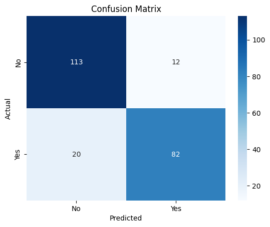

```
Accuracy : 0.8590
```

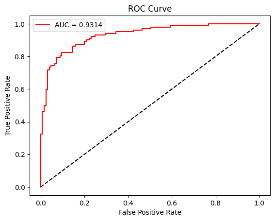

```
AUC     : 0.9314
```

```python
from sklearn.metrics import confusion_matrix, accuracy_score, roc_auc_score, roc_curve
import matplotlib.pyplot as plt
import seaborn as sns

# ── Training predictions ──────────────────────────────────────────────
y_train_pred = model.predict(X_train)
y_train_prob = model.predict_proba(X_train)[:, 1]

# I. Confusion Matrix
print("=== Training Performance ===")
cm = confusion_matrix(y_train, y_train_pred)
sns.heatmap(cm, annot=True, fmt="d", cmap="Blues",
            xticklabels=["No","Yes"], yticklabels=["No","Yes"])
plt.xlabel("Predicted")
plt.ylabel("Actual")
plt.title("Confusion Matrix")
plt.show()

# II. Accuracy
acc = accuracy_score(y_train, y_train_pred)
print(f"Accuracy : {acc:.4f}")

# III. ROC Curve and AUC
auc = roc_auc_score(y_train, y_train_prob)
fpr, tpr, _ = roc_curve(y_train, y_train_prob)
plt.plot(fpr, tpr, color="red", label=f"AUC = {auc:.4f}")
plt.plot([0,1], [0,1], "k--")
plt.xlabel("False Positive Rate")
plt.ylabel("True Positive Rate")
plt.title("ROC Curve")
plt.legend()
plt.show()

print(f"AUC     : {auc:.4f}")
```

**Confusion Matrix:**

- 113 patients correctly predicted as No (True Negative) ✅
- 82 patients correctly predicted as Yes (True Positive) ✅
- 12 patients actually No but predicted as Yes (False Positive) ❌
- 20 patients actually Yes but predicted as No (False Negative) ❌

**Accuracy = 0.8590**

- Model correctly predicted 85.90% of training patients
- Out of 227 training patients, (113+82) = 195 were correct and only 32 were wrong

**ROC Curve & AUC = 0.9314**

- The red curve is far above the dashed line — meaning the model is much better than random guessing
- AUC of 0.93 is considered excellent (closer to 1.0 = perfect model)
- The curve rises steeply towards the top-left corner which is the ideal position

**Overall conclusion:**

- The model fits the training data very well
- AUC 0.93 tells us the model has excellent ability to distinguish between heart disease and healthy patients
- The only concern is 20 False Negatives — these are sick patients predicted as healthy, which is the most dangerous type of error in medical diagnosis

**d) Evaluate the model on testing data**

**I. Confusion matrix**

**II. Accuracy**

**III. ROC curve and AUC**

```
=== Testing Performance ===
```

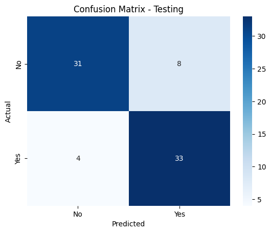

```
Accuracy : 0.8421
```

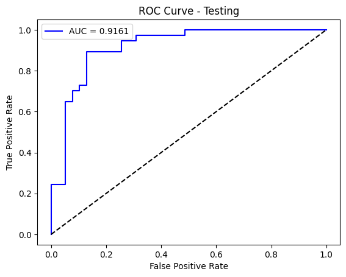

```
AUC     : 0.9161
```

```python
# ── Testing predictions ───────────────────────────────────────────────
y_test_pred = model.predict(X_test)
y_test_prob = model.predict_proba(X_test)[:, 1]

# I. Confusion Matrix
print("=== Testing Performance ===")
cm = confusion_matrix(y_test, y_test_pred)
sns.heatmap(cm, annot=True, fmt="d", cmap="Blues",
            xticklabels=["No","Yes"], yticklabels=["No","Yes"])
plt.xlabel("Predicted")
plt.ylabel("Actual")
plt.title("Confusion Matrix - Testing")
plt.show()

# II. Accuracy
acc = accuracy_score(y_test, y_test_pred)
print(f"Accuracy : {acc:.4f}")

# III. ROC Curve and AUC
auc = roc_auc_score(y_test, y_test_prob)
fpr, tpr, _ = roc_curve(y_test, y_test_prob)
plt.plot(fpr, tpr, color="blue", label=f"AUC = {auc:.4f}")
plt.plot([0,1], [0,1], "k--")
plt.xlabel("False Positive Rate")
plt.ylabel("True Positive Rate")
plt.title("ROC Curve - Testing")
plt.legend()
plt.show()

print(f"AUC     : {auc:.4f}")
```

**Confusion Matrix:**

- 31 patients correctly predicted as No (True Negative) ✅
- 33 patients correctly predicted as Yes (True Positive) ✅
- 8 patients actually No but predicted as Yes (False Positive) ❌
- 4 patients actually Yes but predicted as No (False Negative) ❌

**Accuracy = 0.8421**

- Model correctly predicted 84.21% of testing patients
- Out of 76 testing patients, (31+33) = 64 were correct and only 12 were wrong

**ROC Curve & AUC = 0.9161**

- The blue curve rises steeply towards the top-left corner — sign of a good model
- AUC of 0.91 is considered excellent
- Model is far above the dashed line meaning much better than random guessing

**e) Use the feature selection algorithm to find optimal feature set. How the model perform on training and testing data?**

```python
from sklearn.feature_selection import RFE

# Step 1: Select best 8 features
rfe = RFE(LogisticRegression(max_iter=1000), n_features_to_select=8)
rfe.fit(X_train, y_train)

selected = X_train.columns[rfe.support_].tolist()
print("Selected Features:", selected)

# Step 2: Train new model with selected features only
model_rfe = LogisticRegression(max_iter=1000)
model_rfe.fit(X_train[selected], y_train)

# Step 3: Training performance
y_train_pred = model_rfe.predict(X_train[selected])
y_train_prob = model_rfe.predict_proba(X_train[selected])[:, 1]

print("\n=== Training Performance ===")
print("Confusion Matrix:\n", confusion_matrix(y_train, y_train_pred))
print("Accuracy :", accuracy_score(y_train, y_train_pred))
print("AUC      :", roc_auc_score(y_train, y_train_prob).round(4))

# Step 4: Testing performance
y_test_pred = model_rfe.predict(X_test[selected])
y_test_prob = model_rfe.predict_proba(X_test[selected])[:, 1]

print("\n=== Testing Performance ===")
print("Confusion Matrix:\n", confusion_matrix(y_test, y_test_pred))
print("Accuracy :", accuracy_score(y_test, y_test_pred))
print("AUC      :", roc_auc_score(y_test, y_test_prob).round(4))
```

```
Selected Features: ['Sex', 'ExAng', 'Slope', 'Ca', 'ChestPain_nonanginal', 'ChestPain_nontypical', 'ChestPain_typical', 'Thal_reversable']

=== Training Performance ===
Confusion Matrix:
 [[110  15]
 [ 20  82]]
Accuracy : 0.8458149779735683
AUC      : 0.9166

=== Testing Performance ===
Confusion Matrix:
 [[34  5]
 [ 6 31]]
Accuracy : 0.8552631578947368
AUC      : 0.904
```

**f) Compare the models with and without feature selection, what you observe?**

```python
print("=== Model Comparison ===")
print(f"{'Metric':<20} {'Full Model':>12} {'RFE Model':>12}")
print("-" * 45)
print(f"{'Train Accuracy':<20} {0.8590:>12} {0.8458:>12}")
print(f"{'Test Accuracy':<20} {0.8421:>12} {0.8553:>12}")
print(f"{'Train AUC':<20} {0.9314:>12} {0.9166:>12}")
print(f"{'Test AUC':<20} {0.9161:>12} {0.9040:>12}")
print(f"{'No. of Features':<20} {16:>12} {8:>12}")
```

```
=== Model Comparison ===
Metric                 Full Model    RFE Model
---------------------------------------------
Train Accuracy              0.859       0.8458
Test Accuracy              0.8421       0.8553
Train AUC                  0.9314       0.9166
Test AUC                   0.9161        0.904
No. of Features                16            8
```

**Observations:**

## **6. CART model.**

**a) Please fit a CART model on training data to predict AHD. What is the tree size? Which predictors are used?**

```python
from sklearn.tree import DecisionTreeClassifier

# Fit CART model
cart = DecisionTreeClassifier(random_state=42)
cart.fit(X_train, y_train)

# Tree size
print("Tree Size (nodes):", cart.tree_.node_count)
print("Tree Depth        :", cart.get_depth())

# Predictors used
features_used = X_train.columns[cart.feature_importances_ > 0].tolist()
print("Predictors Used   :", features_used)
```

```
Tree Size (nodes): 81
Tree Depth        : 8
Predictors Used   : ['Age', 'Sex', 'RestBP', 'Chol', 'Fbs', 'MaxHR', 'ExAng', 'Oldpeak', 'Slope', 'Ca', 'ChestPain_nonanginal', 'ChestPain_nontypical', 'ChestPain_typical', 'Thal_normal', 'Thal_reversable']
```

**b) Plot the tree.**

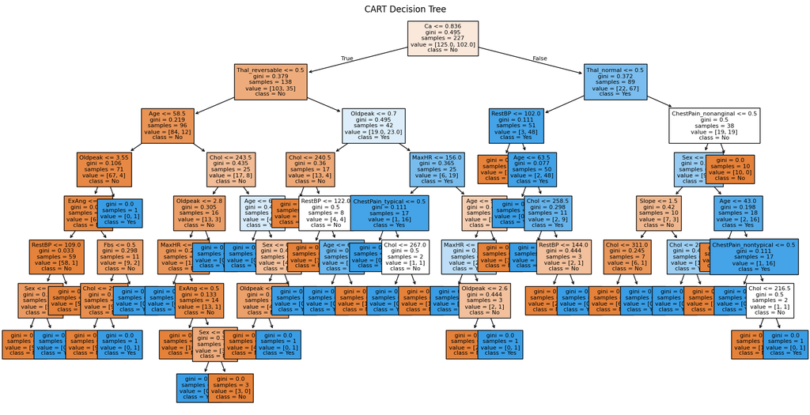

```python
from sklearn.tree import plot_tree
import matplotlib.pyplot as plt

plt.figure(figsize=(20, 10))
plot_tree(cart,
          feature_names=X_train.columns,
          class_names=["No", "Yes"],
          filled=True,
          fontsize=8)
plt.title("CART Decision Tree")
plt.show()
```

**c) Evaluate the prediction accuracy on training and testing data.**

```
=== Training Performance ===
```

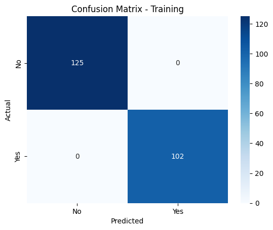

```
=== Testing Performance ===
```

[figure not shown]

```python
# I. Confusion Matrix
print("=== Training Performance ===")
y_train_pred = cart.predict(X_train)
cm = confusion_matrix(y_train, y_train_pred)
sns.heatmap(cm, annot=True, fmt="d", cmap="Blues",
            xticklabels=["No","Yes"], yticklabels=["No","Yes"])
plt.xlabel("Predicted")
plt.ylabel("Actual")
plt.title("Confusion Matrix - Training")
plt.show()


print("=== Testing Performance ===")
y_train_pred = cart.predict(X_train)
cm = confusion_matrix(y_test, y_test_pred)
sns.heatmap(cm, annot=True, fmt="d", cmap="Blues",
            xticklabels=["No","Yes"], yticklabels=["No","Yes"])
plt.xlabel("Predicted")
plt.ylabel("Actual")
plt.title("Confusion Matrix - Testing")
plt.show()

# Training performance
# y_train_pred = cart.predict(X_train)
# print("=== Training Performance ===")
# print("Confusion Matrix:\n", confusion_matrix(y_train, y_train_pred))
# print("Accuracy :", accuracy_score(y_train, y_train_pred))

# Testing performance
# y_test_pred = cart.predict(X_test)
# print("\n=== Testing Performance ===")
# print("Confusion Matrix:\n", confusion_matrix(y_test, y_test_pred))
# print("Accuracy :", accuracy_score(y_test, y_test_pred))
```

**Confusion Matrix — Training:**

- 125 correctly predicted as No ✅
- 102 correctly predicted as Yes ✅
- 0 wrong predictions ❌
- Model got every single training patient correct (100%) — clear sign of overfitting

**d) Please prune the tree using cv.tree function.**

```python
from sklearn.model_selection import GridSearchCV

# Step 1: Test all tree depths from 1 to max depth
param_grid  = {'max_depth': range(1, cart.get_depth() + 1)}

# Step 2: Find best depth using 5-fold cross validation
grid_search = GridSearchCV(DecisionTreeClassifier(random_state=42),
                           param_grid, cv=5, scoring='accuracy')
grid_search.fit(X_train, y_train)

# Step 3: Print best depth
print("Best Tree Depth :", grid_search.best_params_)
print("Best CV Score   :", grid_search.best_score_.round(4))

# Step 4: Build pruned tree with best depth
pruned_cart = DecisionTreeClassifier(random_state=42,
                                     max_depth=grid_search.best_params_['max_depth'])
pruned_cart.fit(X_train, y_train)
```

```
Best Tree Depth : {'max_depth': 3}
Best CV Score   : 0.7487
```

```
DecisionTreeClassifier(max_depth=3, random_state=42)
```

**e) Please plot the CV prediction error as a function of both tree size and k.**

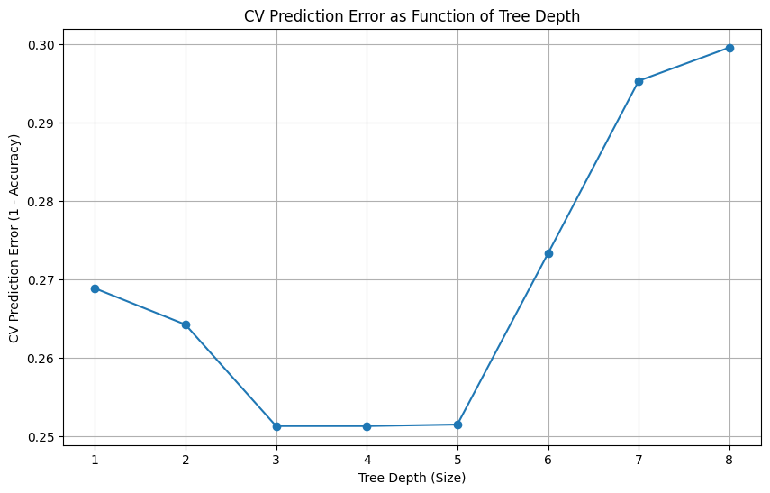

```python
#plotting the CV error as a function of tree depth (size)
plt.figure(figsize=(10, 6)) # set figure size
plt.plot(param_grid['max_depth'], 1 - grid_search.cv_results_['mean_test_score'], marker='o')
plt.xlabel('Tree Depth (Size)')
plt.ylabel('CV Prediction Error (1 - Accuracy)')
plt.title('CV Prediction Error as Function of Tree Depth')
plt.grid(True)
plt.show()
```

**Observations:**

- Error decreases from depth 1 to depth 3 — tree is still learning useful patterns
- Error is lowest and flat between depth 3, 4 and 5 (≈ 0.251) — this is the sweet spot
- Error sharply increases after depth 5 — tree starts overfitting Depth 7 and 8 have the highest error (0.295-0.299) — worst performance

**Best Tree Depth = 3 because:**

- It has the lowest CV error (≈ 0.251)
- It is the simplest tree among the best performing depths
- Simpler tree = less overfitting = better on new data

**f) Please find the best tree size and use prune.misclass function to obtain the best tree.**

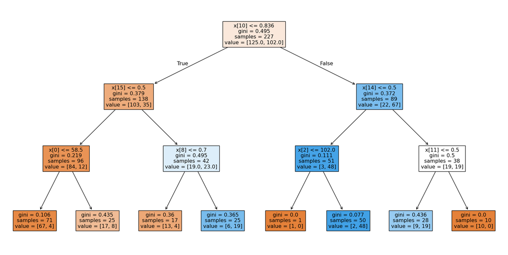

```python
# Plot the pruned tree (the best tree)
plt.figure(figsize=(20, 10))
plot_tree(pruned_cart, filled=True)
plt.show()
```

**g) Evaluate the prediction accuracy of pruned tree on training and testing data.**

```python
# ── g) Evaluate pruned tree ───────────────────────────────────────────
# Training
y_train_pruned = pruned_cart.predict(X_train)
print("=== Pruned Tree Training Performance ===")
print("Confusion Matrix:\n", confusion_matrix(y_train, y_train_pruned))
print("Accuracy :", accuracy_score(y_train, y_train_pruned))

# Testing
y_test_pruned = pruned_cart.predict(X_test)
print("\n=== Pruned Tree Testing Performance ===")
print("Confusion Matrix:\n", confusion_matrix(y_test, y_test_pruned))
print("Accuracy :", accuracy_score(y_test, y_test_pruned))
```

```
=== Pruned Tree Training Performance ===
Confusion Matrix:
 [[108  17]
 [ 16  86]]
Accuracy : 0.8546255506607929

=== Pruned Tree Testing Performance ===
Confusion Matrix:
 [[31  8]
 [10 27]]
Accuracy : 0.7631578947368421
```

**Observations:**

- Training accuracy (85.46%) is higher than testing (76.32%)
- The gap between training and testing is still noticeable but smaller than the full tree
- 10 False Negatives in testing — sick patients predicted as healthy — most dangerous error in medical diagnosis -Overall the pruned tree gives a reasonable and balanced performance on both training and testing data

**h) Compare the models with and without tree pruning, what you observe?**

```python
# ── h) Compare full tree vs pruned tree ──────────────────────────────
print("\n=== Comparison: Full Tree vs Pruned Tree ===")
print(f"{'Metric':<20} {'Full Tree':>12} {'Pruned Tree':>12}")
print("-" * 45)
print(f"{'Train Accuracy':<20} {accuracy_score(y_train, y_train_pred):>12.4f} {accuracy_score(y_train, y_train_pruned):>12.4f}")
print(f"{'Test Accuracy':<20} {accuracy_score(y_test, y_test_pred):>12.4f} {accuracy_score(y_test, y_test_pruned):>12.4f}")
print(f"{'Tree Depth':<20} {cart.get_depth():>12} {pruned_cart.get_depth():>12}")
print(f"{'Tree Nodes':<20} {cart.tree_.node_count:>12} {pruned_cart.tree_.node_count:>12}")
```

[output not shown]

## **7. Ensemble tree.**

**a) Please fit a bagging model using the ‘randomForest’ package. How many trees are fitted?**

```python
from sklearn.ensemble import BaggingClassifier
from sklearn.tree import DecisionTreeClassifier

#  Bagging model (default trees)

bagging_default = BaggingClassifier(estimator=DecisionTreeClassifier(),
                                    random_state=42)
bagging_default.fit(X_train, y_train)
print("=== a) Bagging Default ===")
print("Number of trees:", bagging_default.n_estimators)
```

```
=== a) Bagging Default ===
Number of trees: 10
```

**b) Please fit a bagging model with 50 trees.**

```python
# Fit Bagging model with 50 trees
bagging_50 = BaggingClassifier(estimator=DecisionTreeClassifier(),
                                n_estimators=50,
                                random_state=42)
bagging_50.fit(X_train, y_train)

print("Number of trees fitted:", bagging_50.n_estimators)
```

```
Number of trees fitted: 50
```

**c) Please fit a bagging model with maximum tree size of 4.**

```python
# Fit Bagging model with max tree size of 4
bagging_depth4 = BaggingClassifier(
    estimator   = DecisionTreeClassifier(max_depth=4),
    n_estimators= 100,
    random_state= 42
)
bagging_depth4.fit(X_train, y_train)

print("Bagging model fitted successfully!")
print(f"Number of trees : {bagging_depth4.n_estimators}")
print(f"Max tree depth  : 4")
```

```
Bagging model fitted successfully!
Number of trees : 100
Max tree depth  : 4
```

**d) Which model give the best performance?**

```python
models = {
    "Bagging Default" : bagging_default,
    "Bagging 50 Trees": bagging_50,
    "Bagging Depth 4" : bagging_depth4
}

print("\n=== d) Model Comparison ===")
print(f"{'Model':<20} {'Train Acc':>10} {'Test Acc':>10}")
print("-" * 42)
for name, model in models.items():
    train_acc = accuracy_score(y_train, model.predict(X_train))
    test_acc  = accuracy_score(y_test,  model.predict(X_test))
    print(f"{name:<20} {train_acc:>10} {test_acc:>10}")
```

```
=== d) Model Comparison ===
Model                 Train Acc   Test Acc
------------------------------------------
Bagging Default      0.986784140969163 0.8026315789473685
Bagging 50 Trees            1.0 0.8421052631578947
Bagging Depth 4      0.920704845814978 0.8157894736842105
```

**Observations:**

- **Bagging 50 Trees** has the highest testing accuracy (84.21%) — best model for new data
- **Bagging Default and Bagging 50** Trees both have very high training accuracy (98-100%) — slight overfitting
- **Bagging Depth 4** has the lowest training accuracy (92%) but more balanced — less overfitting
- All three models show a gap between training and testing — this is normal for bagging models
- **Best Model** = Bagging 50 Trees because: Highest test accuracy (84.21%)

**e) Please fit a random forest model with 4 features are considered in each split. Compare the performance of random forest and bagging tree. What you observe?**

```python
from sklearn.ensemble import RandomForestClassifier

# Fit Random Forest with 4 features per split
rf = RandomForestClassifier(n_estimators=100, max_features=4, random_state=42)
rf.fit(X_train, y_train)

# Training and testing performance
print("=== Random Forest ===")
print("Train Accuracy:", accuracy_score(y_train, rf.predict(X_train)))
print("Test Accuracy :", accuracy_score(y_test,  rf.predict(X_test)))

# Compare with best bagging model
print("\n=== Comparison: Random Forest vs Bagging ===")
print(f"{'Model':<20} {'Train Acc':>10} {'Test Acc':>10}")
print("-" * 42)
print(f"{'Bagging 50 Trees':<20} {accuracy_score(y_train, bagging_50.predict(X_train)):>10.4f} {accuracy_score(y_test, bagging_50.predict(X_test)):>10.4f}")
print(f"{'Random Forest':<20} {accuracy_score(y_train, rf.predict(X_train)):>10.4f} {accuracy_score(y_test, rf.predict(X_test)):>10.4f}")
```

```
=== Random Forest ===
Train Accuracy: 1.0
Test Accuracy : 0.8289473684210527

=== Comparison: Random Forest vs Bagging ===
Model                 Train Acc   Test Acc
------------------------------------------
Bagging 50 Trees         1.0000     0.8421
Random Forest            1.0000     0.8289
```

**f) Please visualize the importance of variables in random forest.**

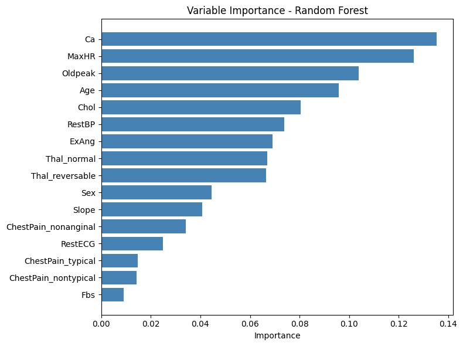

```python
# Get feature importance
importance_df = pd.DataFrame({
    "Feature"   : X_train.columns,
    "Importance": rf.feature_importances_
}).sort_values("Importance", ascending=True)

# Plot
plt.figure(figsize=(8, 6))
plt.barh(importance_df["Feature"], importance_df["Importance"], color="steelblue")
plt.xlabel("Importance")
plt.title("Variable Importance - Random Forest")
plt.tight_layout()
plt.show()
```

**g) Please fit a boosting tree using the ‘gbm’ package with 500 trees. Compare the performance of boosting tree and random forest, which one is better?**

```python
from sklearn.ensemble import GradientBoostingClassifier

# Fit Boosting with 500 trees
boosting = GradientBoostingClassifier(n_estimators=500, random_state=42)
boosting.fit(X_train, y_train)

# Compare Boosting vs Random Forest
print(f"{'Model':<20} {'Train Acc':>10} {'Test Acc':>10}")
print("-" * 42)
print(f"{'Random Forest':<20} {accuracy_score(y_train, rf.predict(X_train)):>10.4f} {accuracy_score(y_test, rf.predict(X_test)):>10.4f}")
print(f"{'Boosting 500':<20} {accuracy_score(y_train, boosting.predict(X_train)):>10.4f} {accuracy_score(y_test, boosting.predict(X_test)):>10.4f}")
```

```
Model                 Train Acc   Test Acc
------------------------------------------
Random Forest            1.0000     0.8289
Boosting 500             1.0000     0.8026
```

**h) Please fit a rulefit model using the ‘pre’ package.**

```python
!pip install imodels
from imodels import RuleFitClassifier
```

```python
# Fit RuleFit model
rulefit = RuleFitClassifier(random_state=42)
rulefit.fit(X_train.values, y_train.values, feature_names=X_train.columns.tolist())

# Performance
print("=== RuleFit Model ===")
print("Train Accuracy:", accuracy_score(y_train, rulefit.predict(X_train.values)))
print("Test Accuracy :", accuracy_score(y_test,  rulefit.predict(X_test.values)))
```

```
=== RuleFit Model ===
Train Accuracy: 0.9118942731277533
Test Accuracy : 0.8157894736842105
```